# Table of Contents

*This notebook contains all the code and explanations that together make up our final project.*

# Introduction

At the ICLR 2015 published a paper called "Continuous Control with Deep Reinforcement Learning". In this paper the authors introduce a refined reinforcement learning algorithm named Deep Deterministic Policy Gradient ("DDPG"). Their reported results indicate that using the same hyperparamters, the DDPG agent robustly solves various physical control problems with continuous action spaces, outperforming a planning algorithm (Tassa et al., 2012) and DPG (Silver et al., 2014) on whose work DDPG is based. A basic reinforcement learning task which was not included in the report, is the continuous version of OpenAI's Mountain Car. In Mountain Car, an underpowered car has to climb a hill from a valley through leveraging the momentum generated by gravity. It receives a reward of 100 for reaching the flag and mild punishments for energy consumption.

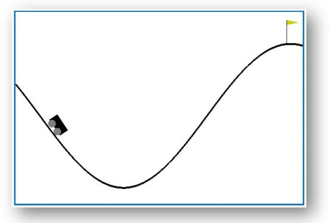

Our project is a replication attempt of the 2015 report, focusing on the mountain car problem with continuous action space. We will begin with writing a tensorflow 2.0.1 implementation of the algorithm and using the exact same parameters as the authors did. Should the agent be unable to solve the problem, we will identify places for improvement and test whether the applied changes yield a positive effect.

# Imports and Global Settings

```python
import numpy as np
import gym as gym
import tensorflow as tf
import matplotlib as mpl
import matplotlib.pyplot as plt
import pandas as pd
import logging

logging.getLogger().setLevel(logging.INFO)
tf.keras.backend.set_floatx('float64')
```

```python
### Only for darkmode users ###
COLOR = 'cyan'
mpl.rcParams['text.color'] = COLOR
mpl.rcParams['axes.labelcolor'] = COLOR
mpl.rcParams['xtick.color'] = COLOR
mpl.rcParams['ytick.color'] = COLOR
```

# DDPG Classes

In order to make sense out of our work, we provide side-by-side view of the DDPG algorithm, taken directly from (Lillicrapt et al. 2016) and a simplified version of our implementation.

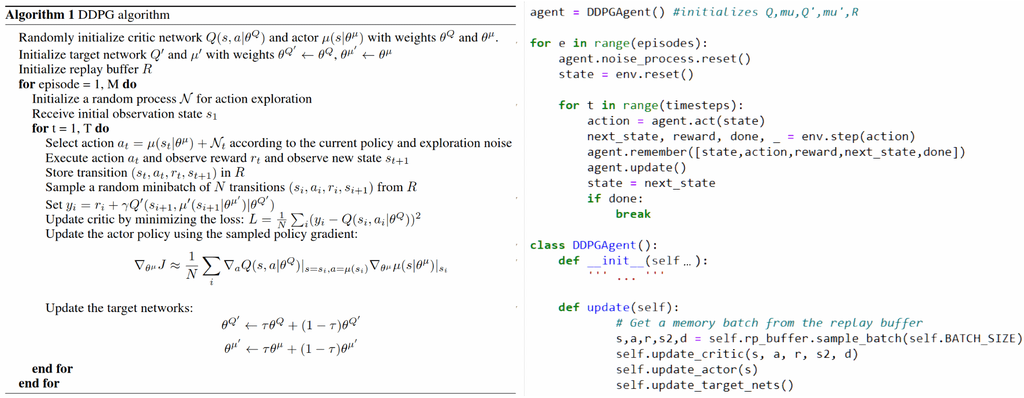

At first glance, the DDPG algorithm is nearly identical to DQN (Mnih et al. 2015). The only major difference lays in the actor update. The implementation of the actor and critic updates in tensorflow 2 will be the core challenge of our project. See training for the complete version.

## ReplayBuffer

Let us begin with the prerequisites for the initialization of our agent. The first one is the replay buffer.

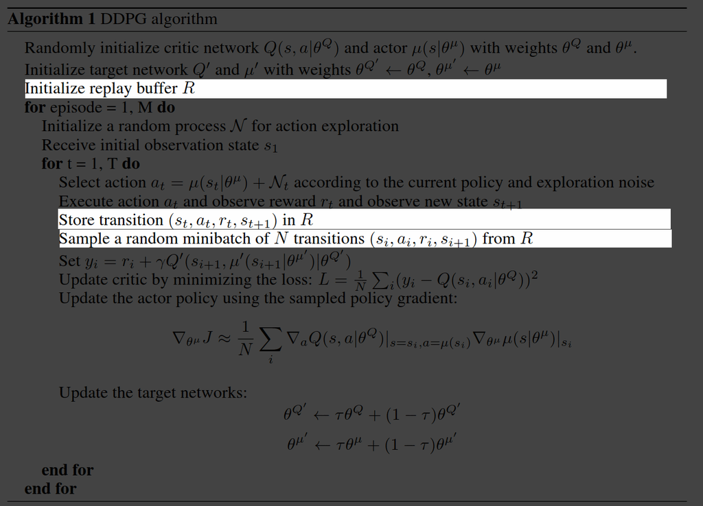

As we can see, the replay buffer only needs two functions. The first function 'store' serves to save memory tuples and the second function 'sample_batch' allows us to randomly sample a minibatch of tuples. We took ourselves the freedom to use a nicely optimized class from openai's github repo and made a tiny addition.

```python
class ReplayBuffer:
    """
    A simple FIFO experience replay buffer for DDPG agents.
    Source: 'https://github.com/openai/spinningup/blob/master/spinup/algos/ddpg/ddpg.py'
    """

    def __init__(self, obs_dim, act_dim, size):
        self.obs1_buf = np.zeros([size, obs_dim], dtype=np.float32)
        self.obs2_buf = np.zeros([size, obs_dim], dtype=np.float32)
        self.acts_buf = np.zeros([size, act_dim], dtype=np.float32)
        self.rews_buf = np.zeros(size, dtype=np.float32)
        self.done_buf = np.zeros(size, dtype=np.float32)
        self.ptr, self.size, self.max_size = 0, 0, size

    def store(self, obs, act, rew, next_obs, done):
        # Our addition
        if len(obs.shape) > 1 or len(next_obs.shape) > 1:
            obs = np.reshape(obs, newshape=(-1,2))

        self.obs1_buf[self.ptr] = obs
        self.obs2_buf[self.ptr] = next_obs
        self.acts_buf[self.ptr] = act
        self.rews_buf[self.ptr] = rew
        self.done_buf[self.ptr] = done
        self.ptr = (self.ptr+1) % self.max_size
        self.size = min(self.size+1, self.max_size)

    def sample_batch(self, batch_size=64):
        idxs = np.random.randint(0, self.size, size=batch_size)
        return dict(obs1=self.obs1_buf[idxs],
                    acts=self.acts_buf[idxs],
                    rews=self.rews_buf[idxs],
                    obs2=self.obs2_buf[idxs],
                    done=self.done_buf[idxs])
```

## Ornstein-Uhlenbeck-Process

The second prerequisite is a noise process to facilitate exploration. Due to the simplicity of the process, we wrote our own implementation.

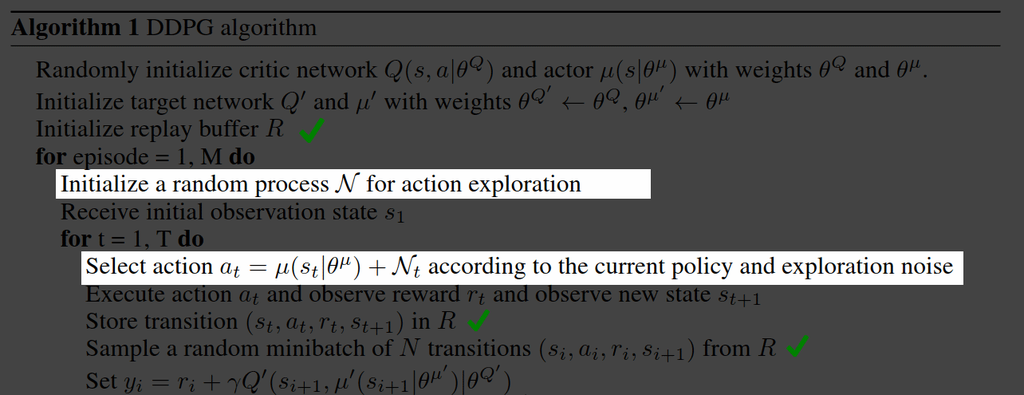

The authors chose an Ornstein-Uhlenbeck process to generate the noise required for exploration. According to them, it is a suitable choice for exploration in physical problems with momentum. The random values of the process are temporary correlated. The increment in the random variable $X$ with mean $\mu$ at time $t$, $dX_t$, is given by the following equation:

$$ dX_t = \theta (\mu - X_t)dt + \sigma dW_t $$

where the first summand is a drift term that directs the process towards the mean and the second summad is the differential of a Wiener Process. The differential of a Wiener Process is normally distributed. This means, the second summand is a gaussian with standard deviation $\sigma$. (Wikipedia)

```python
class OrnsteinUhlenbeck():
    def __init__( self, action_dim=1,x0=None,mu=0.0, sigma=0.3, theta=0.15 ):
        self.action_dim = action_dim
        self.mu = mu
        self.sigma = sigma
        self.theta = theta
        self.x = x0
        self.dt = 1
        if x0 is None: self.reset()


    def sample(self):
        """
        Calculates the next value of x depending on the last value of x and the
        process' parameters.

        Returns:
            x: The next value sampled from a Ornstein Uhlenbeck Process
        """

        drift = self.theta*(self.mu-self.x)*self.dt
        dWt  = np.random.normal(0,1,size=self.action_dim)
        dxt = drift + self.sigma*dWt
        self.x = self.x + dxt
        return self.x

    def reset(self):
        self.x = np.random.normal(loc=0,scale=self.sigma,size=self.action_dim)
```

## Agent

### Initialization

Next, we tackle the initialization of our agent.

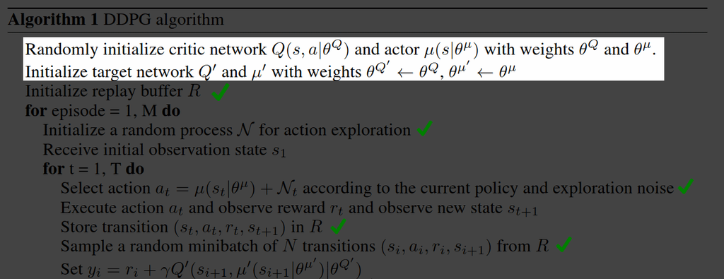

Refer to the functions

`initialize_actor`, `initialize_critic`, `initialize_target_critic` and `initialize_target_actor`

in Agent Class for details.

### Updates

#### Critic

Updating the critic parameters is, in this case, synonymous with updating the parameters of the Q-Function. Like in discrete Q-Learning, we must first compute the targets for the Bellman Equation:

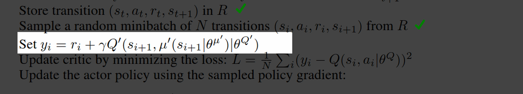

We used tensorflow's gradient tape to record the operations that led to the computation of the target. The critical line in which we bring all the components together, is

```
critic_targets = rewards + self.GAMMA*(1-dones)*target_critic_out (193).
```

As a loss function, we used the mean squared error between the target and the output of the critic and an L2 regularizer.

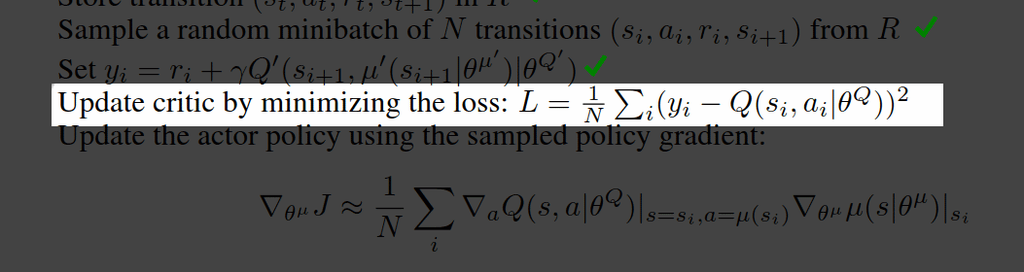

Refer to `DDPGAgent.update_critic` for the computation of the error and the update of the critic.

#### Actor

The update of the actor is based on the DPG algorithm by (Silver et al. 2014). In the image below, $J$ signifies the return (expected long term rewards) if we deterministically follow a policy with parameters $\theta^{\mu}$. In the critic update, we computed the gradient with respect to $\theta^{Q}$ to minimize the loss function. Here, we compute the gradient with respect to $\theta^{\mu}$ to maximize the return for all samples from the minibatch and then take the average gradient, also refered to as "sampled policy gradient".

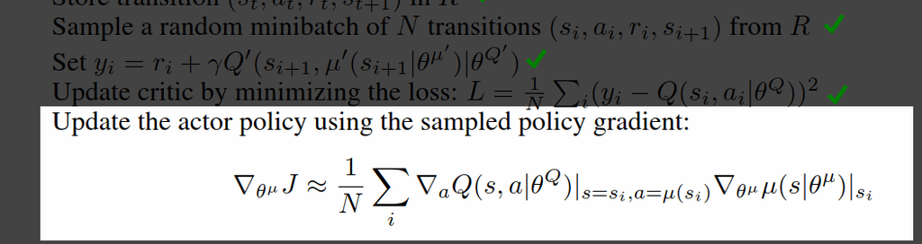

Please refer to `DDPGAgent.update_actor` in the cell below for further details.

## Agent Class

The cell below initiates all the components,parameters and updates that were briefly discussed in this section.

```python
from tensorflow.keras.layers import Input, concatenate, Dense, BatchNormalization
from tensorflow.keras.models import Model
from tensorflow.keras.optimizers import Adam
from tensorflow.keras.losses import MSE
from tensorflow.keras.initializers import RandomUniform as uniform
from tensorflow.keras.activations import relu

class DDPGAgent():
    '''
    Initiates all subcomponents required for the DDPG algorithm
    with standard parameter values as specified by (Lillicrap et al, 2015)
    '''

    def __init__(self,
                 env=None,
                 actor=None,
                 critic=None,
                 gamma=0.99,
                 tau=0.001,
                 batch_size=64,
                 replay_buffer_size=int(1e6),
                 noise_scale=0.3,
                 epsilon=0.999,
                 lr_actor=1e-4,
                 lr_critic=1e-3,
                 l2_weight_decay=1e-2,
                 actor_nd1=400,
                 actor_nd2=300,
                 action_scale=1.0,
                 critic_nd1=400,
                 critic_nd2=300,
                 overrepresent_goals=False,
                 q_modification=False):

        # Class Constants
        self.ENV = env
        self.GAMMA = gamma
        self.TAU = tau
        self.BATCH_SIZE = batch_size
        self.RP_BUFFER_SIZE = replay_buffer_size
        self.NOISE_SCALE = noise_scale
        self.EPSILON = epsilon # For reducing noise with increasing timesteps

        #Environment Constants for convenience
        self.action_dim = env.action_space.shape[0]
        self.observation_dim = env.observation_space.shape[0]
        self.action_high = env.action_space.high
        self.action_low = env.action_space.low

        #Replaybuffer
        self.rp_buffer = ReplayBuffer(self.observation_dim, self.action_dim,
                                      self.RP_BUFFER_SIZE)
        #Remembering
        self.overrepresent_goals = overrepresent_goals
        self.q_modification = q_modification

        #Noise Process
        self.noise_process = OrnsteinUhlenbeck(self.action_dim, sigma=noise_scale)

        #Networks
        self.actor  = self.initialize_actor(actor_nd1,
                                            actor_nd2,
                                            action_scale) if actor == None else actor
        self.critic = self.initialize_critic(critic_nd1,
                                             critic_nd2) if critic == None else critic
        self.target_actor  =  self.initialize_target_actor()
        self.target_critic =  self.initialize_target_critic()

        #Optimizers
        self.optimizer_actor = tf.keras.optimizers.Adam(lr_actor)
        self.optimizer_critic = tf.keras.optimizers.Adam(lr_critic)
        self.l2_weight_decay = l2_weight_decay

        #For result visualization
        self.actor_losses = []
        self.critic_losses = []


    #=============================== ACTOR ========================================#
    def initialize_actor(self,nd1,nd2,action_scale):
        ''' Initializes a feedforward neural network that serves as a policy for this agent.'''

        # Initializers for different layers
        init_h1 = uniform(-1/np.sqrt(self.observation_dim), 1/np.sqrt(self.observation_dim))
        init_h2 = uniform(-1/np.sqrt(nd1) , 1/np.sqrt(nd1))
        init_out = uniform(-3e-3, 3e-3)

        # Input Layer
        x = Input(shape=(self.observation_dim,) ) # Dynamic input layer
        x_norm = BatchNormalization()(x)
        # First Hidden layer
        D1 = Dense(nd1,
                  activation=None,
                  kernel_initializer=init_h1,
                  bias_initializer=init_h1)(x_norm)
        D1_norm = BatchNormalization()(D1)
        D1_activation = relu(D1_norm)

        # Second Hidden layer
        D2 = Dense(nd2,
                  activation=None,
                  kernel_initializer=init_h2,
                  bias_initializer=init_h2)(D1_activation)
        D2_norm = BatchNormalization()(D2)
        D2_activation = relu(D2_norm)

        # Output Layer
        y = Dense(self.action_dim,
                  "tanh",
                  kernel_initializer=init_out,
                  bias_initializer=init_out)(D2_activation)

        y = tf.multiply(y, action_scale)

        # Model Compilation
        actor = Model(inputs=x, outputs=y)
        actor.compile(optimizer='adam', loss="MSE") # these are placeholders, we fit the actor manually

        return actor

    def act(self,states,exploration=True):
        ''' Compute an action with optional noise

        params:
            state: (np.array) Batch of states with shape (batch_size, state_dim)
            exploration: (bool) Indicates wether noise should be added
        returns:
            action: (np.array) Batch of actions with shape (batch_size, action_dim)
        '''

        # Check wether states have the right shapes, should be (batch size, self.action_dim)
        if len(states.shape) == 1:
            states = np.expand_dims(states, axis=0)

        if states.shape[1] != self.observation_dim:
            states = states.reshape(-1, self.observation_dim)

        action = self.actor(states)

        # Add noise according to ornstein uhlenbeck process
        if exploration==True:
            noise = self.noise_process.sample()
            action += noise*self.EPSILON

        # Clip the action to the bounds given by the environment (usually unnecessary since
        # most environments have an action space of [-1,1] and tanh(x) -> [-1,1])

        action = np.clip(action, self.action_low, self.action_high)

        return action

    #=============================== CRITIC =======================================#
    def initialize_critic(self, nd1, nd2):
        ''' Initialize a feedforward neural network that serves as the action-value function (or 'Q').'''

        # Initializers for different layers
        init_h1 = uniform(-1/np.sqrt(self.observation_dim), 1/np.sqrt(self.observation_dim))
        init_h2 = uniform(-1/np.sqrt(nd1) , 1/np.sqrt(nd1))
        init_out = uniform(-0.001, 0.001)
```

```python
        # Input Layer
        s = Input(shape=(self.observation_dim,))
        s_norm = BatchNormalization()(s)
        # First Hidden Layer
        D1 = Dense(nd1,
                  activation=None,
                  kernel_initializer=init_h1,
                  bias_initializer=init_h1)(s_norm)
        D1_norm = BatchNormalization()(D1)
        D1_activation = relu(D1_norm)

        # Second Hidden layer
        # Additional Input: Action
        a = Input(shape=(self.action_dim,))
        D1_a = concatenate([D1_activation,a], axis=1)

        D2= Dense(nd2,
                  "relu",
                  kernel_initializer=init_h2,
                  bias_initializer=init_h2)(D1_a)

        # Output Layer
        y = Dense(1,
                  "sigmoid",
                  kernel_initializer=init_out,
                  bias_initializer=init_out)(D2)

        # Model Compilation
        critic = Model(inputs=[s,a], outputs=y)
        critic.compile(optimizer="adam", loss="MSE", metrics=["mae"]) # Place Holders, we fit the critic manually
        return critic

    #=============================== TARGET NETWORKS ===============================#
    def initialize_target_actor(self):

        if "saved_model" in str(type(self.actor)):
            return None
        target_actor = tf.keras.models.clone_model(self.actor)
        target_actor.set_weights(self.actor.get_weights())
        return target_actor

    def initialize_target_critic(self):
        if "saved_model" in str(type(self.critic)):
            return None
        target_critic = tf.keras.models.clone_model(self.critic)
        target_critic.set_weights(self.critic.get_weights())
        return target_critic

    #=============================== UPDATES =======================================#

    def update(self):
        ''' Calls the update functions of all networks with a memory batch from the replay buffer. '''
        # Get a memory batch from the replay buffer
        batch = self.rp_buffer.sample_batch(self.BATCH_SIZE)
        states, actions, rewards, states2, dones = batch.values()

        # Convert memory batches (ndarrays) to tensors with 'cvt()' for gradienttape to work.
        states = self.cvt(states)
        actions = self.cvt(actions)
        rewards = self.cvt(rewards)
        states2 = self.cvt(states2)
        dones = self.cvt(dones)

        # Update the networks
        self.update_critic(states, actions, rewards, states2, dones)
        self.update_actor(states)
        self.update_target_nets()

    def update_critic(self,states, actions, rewards, states2, dones):
        with tf.GradientTape() as tp:
            ''' The Bellman Update with MSE and L2 regularization'''
            # s,a
            critic_inputs = [states, actions]

            # Q(s,a)
            critic_out = self.critic(critic_inputs)

            # P^(s')            (= a')
            target_actions = self.target_actor(states2)

            # Q^(s', P^(s'))   ( = Q^(s',a') )
            target_critic_out = self.target_critic([states2, target_actions])

            # y = r + gamma * (1-d) * Q^( s',  P^(s') )
            critic_targets = rewards + self.GAMMA*(1-dones)*target_critic_out

            # MSE = 1/N * sum( ( y-Q(s,a) )² )
            mse = MSE(critic_targets,critic_out)

            # L2 = c*1/2*sum(weights**2)
            sum_weights_sq_per_layer = [tf.reduce_sum(v**2) for v in self.critic.trainable_variables
                       if "bias" not in v.name]

            sum_weights_sq = tf.reduce_sum(sum_weights_sq_per_layer)

            l2 = self.l2_weight_decay * 1/2 * sum_weights_sq

            # Loss = MSE + L2
            critic_loss = mse + l2
            self.critic_losses.append(critic_loss)

            # Apply Gradients
            critic_gradients = tp.gradient(critic_loss, self.critic.trainable_variables)
            self.optimizer_critic.apply_gradients(zip(critic_gradients, self.critic.trainable_variables))

        del tp

    def update_actor(self, states):
        ''' Update of the actor weights with with the scope of maximizing Q '''

        with tf.GradientTape(persistent=True) as tp: # Has to be persistent since we compute multiple gradients
            # P(s)      64 Values
            actions = self.actor(states)

            # Q(s,P(s)) 64 Values
            Qs = self.critic([states,actions])
            self.actor_losses.append(np.mean(Qs))

            # Compute the individual gradient vectors for each Q
            # list of 64 gradients, each gradient is a len-6-list: [(2,400),(400),(400,300),(300),(300,1),(1)],
            # because our actor has 3 layers and 3 biases.

            gradients = [tp.gradient(Q, self.actor.trainable_variables) for Q in Qs]
            # Yes, computing gradients inside a persistent gradient tape is inefficient but computing
            # them outside just creates gradients with null entries.

            logging.debug(f'''gradients has self.batch_size entries:
                              {len(gradients) == self.BATCH_SIZE},
                              gradients[0] has as many entries as there are layers and biases in actor:
                              {len(gradients[0]) == len(self.actor.trainable_variables)}
                            '''
                         )



        # Neither a list nor a numpy array of tensors with different shapes is convertable
        # to a tensor by tensorflow, which is why we can't simply call tf_reduce_mean() on gradients.
        # Therefore, we will compute the mean of the gradients manually in
        # self.mean_of_gradients()

        # Compute the sampled policy gradient
        mean_actor_gradient = self.mean_of_gradients(gradients)

        logging.debug(f'''Mean_actor gradient should have the following properties:
                        len == len(actor tv) : {len(mean_actor_gradient) == len(self.actor.trainable_variables)}
                        shape of G1 == shape of D1: {mean_actor_gradient[0].shape == gradients[0][0].shape}
                        No Nones : {not None in mean_actor_gradient[0].numpy()}
                        ''')
```

```python
        # Apply Gradient
        # self.optimizer_actor is Adam. Adam optimizes the weights based on the negative gradient
        # to minimize the cost function (Q in this case). We want to maximize Q. Therefore, we flip
        # the sign of the mean gradient for each layer before we apply it.
        mean_actor_gradient = [-g for g in mean_actor_gradient]
        self.optimizer_actor.apply_gradients(zip(mean_actor_gradient, self.actor.trainable_variables))

        del tp

    def update_target_nets(self):
        '''Soft Update for Target networks'''
        aw = agent.actor.get_weights()           #actor weights
        cw = agent.critic.get_weights()          #critic weights
        taw = agent.target_actor.get_weights()   #target actor weights
        tcw = agent.target_critic.get_weights()  #target critic weights

        ntaw = [agent.TAU*w + (1-agent.TAU)*tw for w, tw in zip(aw,taw)] #new target actor weights
        agent.target_actor.set_weights(ntaw)

        ntcw = [agent.TAU*w + (1-agent.TAU)*tw for w, tw in zip(cw,tcw)] #new target critic weights
        agent.target_critic.set_weights(ntcw)


    def remember(self, state_transitions):
        '''
        Function to store a list of state_transitions
        '''
        # state_transitions[i] = [s_i,a_i,r_i,s'_i,d_i]
        # 0:state, 1:action, 2:reward, 3:next_state, 4:done
        if type(state_transitions[0]) != list:
            state_transitions = [state_transitions]

        # Modify the rewards of the trajectory
        if self.q_modification:
            n_sts = len(state_transitions)
            # Modifiy the rewards of the states that preceeded it
            for i in range(2,min(50, n_sts)):
                state_transitions[-i][2] += state_transitions[-i+1][2] * self.GAMMA

        # if we want to overrepresent high reward states and the reward of the last state is very high:
        if self.overrepresent_goals and state_transitions[-1][2] >= 50:
            # Store the sequence of states (or ONE state, depending on the value of "state_transitions")
            # ten times in the replay buffer to increase the probability that it is learned
            state_transitions *= 10

        # Add State transitions to replay buffer
        for state,action,reward,next_state,done in state_transitions:
            agent.rp_buffer.store(state.reshape(-1,self.observation_dim),
                                  action,
                                  reward,
                                  next_state.reshape(-1,self.observation_dim),
                                  done)

    #== Utils ==#
    def cvt(self,x):
        '''quickly converts arrays to tensors'''
        return tf.convert_to_tensor(x, dtype=tf.float64)

    def mean_of_gradients(self,gradients:list):
        ''' Takes a list of gradient lists and returns a list with the mean of all gradients'''

        nlayers = len(gradients[0])
        mean_gradients = list(np.zeros(nlayers)) # initialize a list with nlayers entries

        #For each layer i
        for i in range(nlayers):
            sum_i = 0
            #For all gradients that have been computed for this layer:
            for j in range(len(gradients)):
                sum_i += gradients[j][i]
            #Compute the average gradient for the ith layer
            avg_i = sum_i / len(gradients)
            mean_gradients[i] = avg_i

        return mean_gradients
```

# Training Algorithm

```python
def train_agent(agent,
                ENV,
                episodes=100,
                timesteps=800,
                train_interval=1,
                render=False,
                monitor=True,
                verbose=True,
                save_progress=True,
                save_interval=1,
                agent_name="",
                save_results=True,
                epsilon_decay=False,
                short_term_memory=1
               ):

    path = "saved_models\\" + agent_name + "\\"

    episodic_rewards = []

    for e in range(1, episodes+1):
        logging.info(f'Episode {e} out of {episodes}')

        if save_progress and e%save_interval==0:
            tf.saved_model.save(agent.actor,  export_dir = path+f"e{e}_actor")
            tf.saved_model.save(agent.critic, export_dir = path+f"e{e}_critic")

        rewards = []
        state_transitions = []
        state = env.reset()
        agent.noise_process.reset()

        for t in range(timesteps):
            if monitor and t%50==0:
                logging.info(f'episode {e}, timestep {t}')

            # Act
            try:
                action = agent.act(state, exploration=True)
            except:
                print(f"Bad state:  {state}")
                break
            # Observe
            next_state, reward, done, _ = env.step(action)
            if render: env.render()

            # Remember
            state_transitions.append([state,action,reward,next_state,done])

            if t % short_term_memory == 0:
                agent.remember(state_transitions)
                state_transitions = []

            # Update
            if t % train_interval == 0 and agent.rp_buffer.size >= agent.BATCH_SIZE:
                agent.update()


            # (Update State)
            state = next_state
            # (Record Performance)
            rewards.append(reward)

            # End
            if done or t == timesteps-1:
                # Save Episode Score
                episodic_reward = sum(rewards)
                episodic_rewards.append(episodic_reward)
                # Print Info
                if verbose:
                    info = f" in a goal state after {t} steps " if done else " "
                    logging.info(f'Episode ended{info}with cumulative reward of:{episodic_reward}')

                if epsilon_decay:
                    agent.EPSILON *= agent.EPSILON
                break

    env.close()

    episodic_rewards = pd.Series(episodic_rewards)
    actor_losses = pd.Series(agent.actor_losses)
    critic_losses = pd.Series(agent.critic_losses)
    if save_results:
        episodic_rewards.to_csv(f"results/episodic_rewards/{agent_name}_e{str(episodes)}.csv")
        actor_losses.to_csv(f"results/losses/{agent_name}_e{str(episodes)}_actor.csv")
        actor_losses.to_csv(f"results/losses/{agent_name}_e{str(episodes)}_critic.csv")

    return episodic_rewards
```

# Original DDPG

```python
####### Pretrained  #########
agent_name="original_ddpg"
env = gym.make("MountainCarContinuous-v0")
actor = tf.saved_model.load(f"saved_models/{agent_name}/e100_actor")
agent = DDPGAgent(env=env,actor=actor)
episodic_rewards = pd.read_csv(f"results/episodic_rewards/{agent_name}_e100.csv", header=None)[1]
```

## Results

```python
def plot_results(episodic_rewards, agent_name="agent", save=True):
    plt.figure(figsize=(9, 3), dpi=100)
    plt.scatter(range(len(episodic_rewards)),episodic_rewards, lw=0.7, label="raw")
    plt.gca().set(title=f"Episodic rewards of {agent_name}",
                  xlabel="Episode",
                  ylabel="reward")
    plt.grid()
    if save: plt.savefig(f"results/episodic_rewards/{agent_name}")
    plt.show()
```

### Episodic Rewards during Training

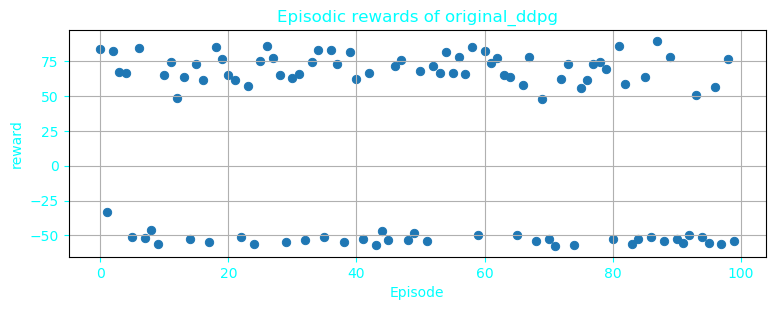

```python
plot_results(episodic_rewards, agent_name)
```

The agent receives a reward signal of 100, whenever he reaches the flag on top of the hill and gets mild punishments (negative rewards) for using the gas. We can interpret the spikes in the graph above as episodes in which the agent was able to reach the goal. We can see that the epsiodes in which the agent reached the goal are scattered in a seemingly arbitrary manner.

### Episodic Rewards during Testing

```python
def test_agent(agent,
                ENV,
                episodes=100,
                timesteps=800,
                render=False,
                verbose=True,
                agent_name="",
                save_results=True,
                normalize=False,
                mu=0,
                sigma=1
              ):

    episodic_rewards = []

    for e in range(1, episodes+1):
        logging.info(f'Episode {e} out of {episodes}')
        rewards = []
        state = env.reset()

        for t in range(timesteps):
            action = agent.act(state, exploration=False)
            if normalize:
                action = (action-mu)/sigma
            state, reward, done,_ = env.step(action)
            if render: env.render()
            rewards.append(reward)
            if done or t == timesteps-1:
                # Save Episode Score
                episodic_reward = sum(rewards)
                episodic_rewards.append(episodic_reward)
                # Print Info
                if verbose:
                    info = f" in a goal state after {t} steps " if done else " "
                    logging.info(f'Episode ended{info}with cumulative reward of:{episodic_reward}')
                break

    env.close()

    episodic_rewards = pd.Series(episodic_rewards)
    if save_results:
        episodic_rewards.to_csv(f"results/episodic_rewards/{agent_name}_e{str(episodes)}_test.csv")
    return episodic_rewards

test_results = test_agent(agent, env, agent_name="original_ddpg", verbose=False, episodes=10)
```

```
INFO:root:Episode 1 out of 10
INFO:root:Episode 2 out of 10
INFO:root:Episode 3 out of 10
INFO:root:Episode 4 out of 10
INFO:root:Episode 5 out of 10
INFO:root:Episode 6 out of 10
INFO:root:Episode 7 out of 10
INFO:root:Episode 8 out of 10
INFO:root:Episode 9 out of 10
INFO:root:Episode 10 out of 10
```

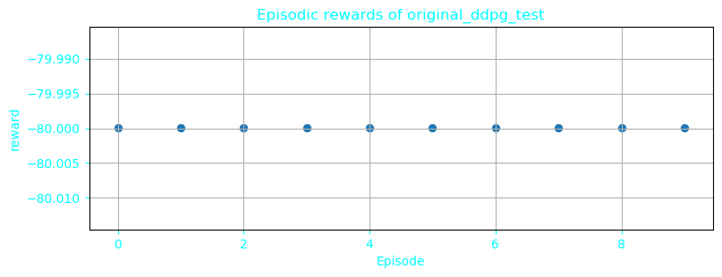

```python
plot_results(test_results, agent_name="original_ddpg_test")
```

## Identifiying misbehavior

First of all, let us look at the way the agent behaves.

### Demo

```python
agent_name="original_ddpg"
actor = tf.saved_model.load(f"saved_models/{agent_name}/e100_actor")
agent = DDPGAgent(env, actor=actor)
def demo(agent,env):
    E = 1
    T = 500
    actions = []
    for e in range(E):
        state = env.reset()
        for t in range(T):
            a = agent.act(state, exploration=False)
            actions.append(a)
            state,a,r,d = env.step(a)
            env.render()
            if d:
                break
    env.close()
    return np.array(actions).reshape(T,1)

actions = demo(agent,env)
```

The agent seems to have learned a policy that continuously drives him to the right. Let's look at the actions and plot them against the entire state space just to make sure.

### Action Plot

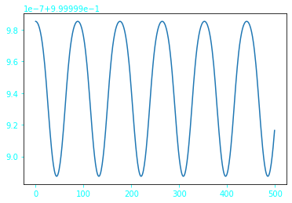

```python
plt.plot(actions)
```

From this plot we can learn that there probably is a linear relationship between the position and the action output of the agent. Because, as the agent oscillates between two positions, his action outputs oscillate as well. Let us plot the policy (actions over the entire state space) to gain a better understanding of the influences of position and velocity.

### Policy Plot

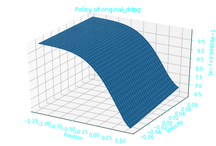

```python
from mpl_toolkits.mplot3d import Axes3D

def plot_policy(agent, agent_name="agent"):
    pos = np.arange(-1.2,0.6,0.05)
    vel = np.arange(-0.07, 0.075, 0.005)

    P, V = np.meshgrid(pos,vel)
    A = np.zeros(P.shape)

    for i in range(P.shape[0]):
        for j in range(P.shape[1]):
            state = np.array([ [ P[i,j], V[i,j] ] ])
            state = state.reshape(-1,2)
            A[i,j] = agent.actor(state)

    fig = plt.figure()
    ax = Axes3D(fig)
    ax.plot_surface(P,V,A)
    plt.gca().set(xlabel="Position", ylabel="Velocity", title=f"Policy of {agent_name}")
    plt.show()

plot_policy(agent, agent_name=agent_name)
```

[output not shown]

It is unfortunate that velocity bears such a little influence on the action, as it is arguably the only relevant factor for maximizing the episodic reward. On the upside of things, however, there is a reasonable albeit small development within the policy. Towards position 0.50 we can see that high velocities cause greater actions (greater acceleration) than low velocities. This is a desired effect because accelerating while the velocity is negativ leads to an unnecessary loss of energy, wheras accelerating while the velocity is positive, makes use of the momentum.

Concerning 2, it seems like the scale and shift of the action are off. Perhaps, if we normalize them this time, while running the test, we can get better results:

### Episodic Rewards of Test with normalized Actions

```
INFO:root:Episode 1 out of 10
INFO:root:Episode ended with cumulative reward of:-51.07655704940668
INFO:root:Episode 2 out of 10
INFO:root:Episode ended with cumulative reward of:-51.008828177194374
INFO:root:Episode 3 out of 10
INFO:root:Episode ended with cumulative reward of:-51.8507524047163
INFO:root:Episode 4 out of 10
INFO:root:Episode ended with cumulative reward of:-73.10300051903572
INFO:root:Episode 5 out of 10
INFO:root:Episode ended with cumulative reward of:-73.96979506586223
INFO:root:Episode 6 out of 10
INFO:root:Episode ended with cumulative reward of:-46.63225240002497
INFO:root:Episode 7 out of 10
INFO:root:Episode ended with cumulative reward of:-72.65820308024078
INFO:root:Episode 8 out of 10
INFO:root:Episode ended with cumulative reward of:-64.30212086646858
INFO:root:Episode 9 out of 10
INFO:root:Episode ended with cumulative reward of:-54.98361180603196
INFO:root:Episode 10 out of 10
INFO:root:Episode ended with cumulative reward of:-46.54120273250429
```

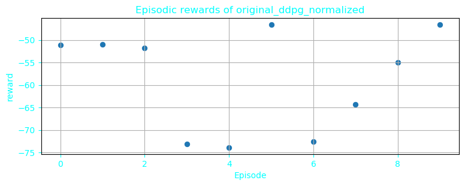

```python
episodic_rewards = test_agent(agent,
                              agent_name+"_normalized",
                              episodes=10,
                              normalize=True,
                              mu=np.mean(actions),
                              sigma=np.std(actions))
plot_results(episodic_rewards, agent_name+"_normalized")
```

Normalizing the actions did not really improve the episodic rewards.

## Room for improvement

Room for improvement lays in the following areas:

- Generally speaking, the boundaries of the action space are a bit high. If the agent can accelerate with a force of 1. He is not really forced to actively use momentum.
  - $\rightarrow$ We will scale the output of the actor by 0.5.
- For a low dimensional problem like this one, the networks have far too many parameters that introduce variability.
  - $\rightarrow$ We will reduce the neuron counts in the first and second layer to 30 and 40.
- The rewards are sparse, the agent only has a slim chance of encountering goal states during memory replay.
  - $\rightarrow$ We will overrepresent goal states in the replay buffer, by adding ten identical entries per goal state.
- The noise process has a mean of 0 and a standard deviation of 0.3. This is too high for an action space of (-1,1) as it makes finely adjusted actions practically impossible.
  - $\rightarrow$ We will gradually reduce it to 0.005 over the course of training, using a parameter $ \mathcal{E} $
- The temporal correlation between goal states and the trajectories that led to them, is only implicitly learned by the Q-Function
  - $\rightarrow$ We could collect experiences, that lead up to goal states, and assign new rewards based on their distance from the goal states. This basically corresponds to explicit Q-Learning. But we'll only try this, if the above modifications do not yield any positive results.

# Modifications

## Modified DDPG

Our first modified agent features all the modifications above except for explicit Q-Learning

```python
##### Pretrained #####
agent_name="modified_ddpg"
env = gym.make("MountainCarContinuous-v0")
actor = tf.saved_model.load(f"saved_models/{agent_name}/e100_actor")
agent = DDPGAgent(env=env,actor=actor)
episodic_rewards = pd.read_csv(f"results/episodic_rewards/{agent_name}_e100.csv", header=None)[1]
```

### Results

#### Episodic Rewards during Training

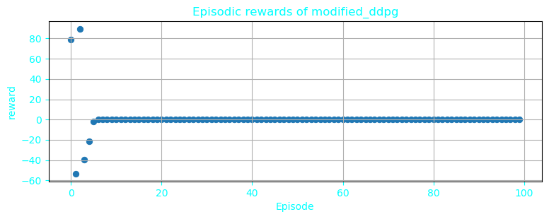

```python
plot_results(episodic_rewards,agent_name)
```

After 10 Epsiodes the noise was scaled down to 0.46, which is still fairly high. Nonetheless, the agent never managed to reach the goal state again. In fact the entire run was characterized by idleness, which we cannot explain for now.

#### Episodic Rewards during Testing

```
INFO:root:Episode 1 out of 10
INFO:root:Episode 2 out of 10
INFO:root:Episode 3 out of 10
INFO:root:Episode 4 out of 10
INFO:root:Episode 5 out of 10
INFO:root:Episode 6 out of 10
INFO:root:Episode 7 out of 10
INFO:root:Episode 8 out of 10
INFO:root:Episode 9 out of 10
INFO:root:Episode 10 out of 10
```

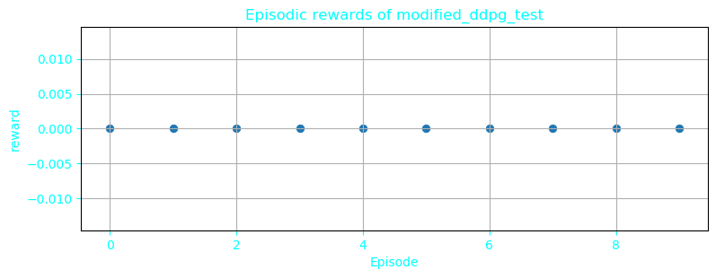

```python
test_results = test_agent(agent, env, agent_name=agent_name, verbose=False, episodes=10)
plot_results(test_results,agent_name+"_test")
```

These results suggest that the output of the agent is 0 most of the time. This is congruent with the behavior during training.

#### Action Plot

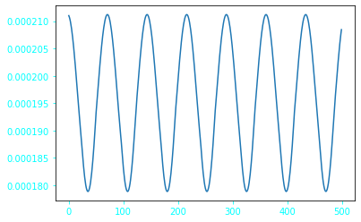

```python
actions = demo(agent,env)
plt.plot(actions)
```

Now, again the scale of the action output is even smaller and oscillating in the same expected manner as the original agent.

#### Policy Plot

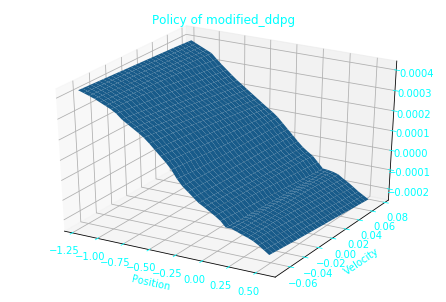

```python
plot_policy(agent, agent_name=agent_name)
```

## Q-modified DDPG

```python
###### Pretrained #####
agent_name="q_modified_ddpg"
env = gym.make("MountainCarContinuous-v0")
actor = tf.saved_model.load(f"saved_models/{agent_name}/e100_actor")
agent = DDPGAgent(env=env,actor=actor)
episodic_rewards = pd.read_csv(f"results/episodic_rewards/{agent_name}_e100.csv", header=None)[1]
```

### Results

#### Episodic Rewards during Training

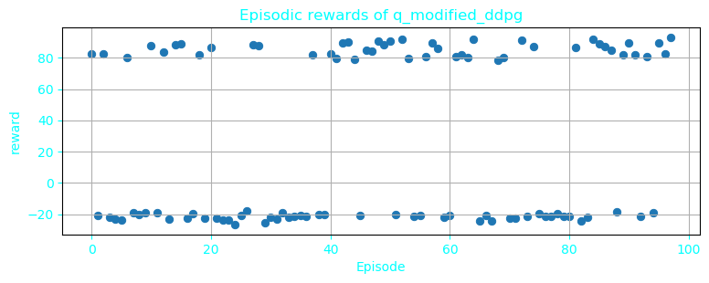

```python
plot_results(episodic_rewards, agent_name)
```

#### Episodic Rewards during Testing

```
INFO:root:Episode 1 out of 10
INFO:root:Episode 2 out of 10
INFO:root:Episode 3 out of 10
INFO:root:Episode 4 out of 10
INFO:root:Episode 5 out of 10
INFO:root:Episode 6 out of 10
INFO:root:Episode 7 out of 10
INFO:root:Episode 8 out of 10
INFO:root:Episode 9 out of 10
INFO:root:Episode 10 out of 10
```

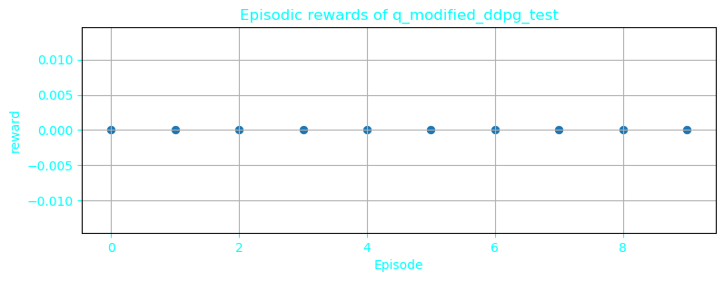

```python
test_results = test_agent(agent, env, agent_name=agent_name, verbose=False, episodes=10)
plot_results(test_results,agent_name+"_test")
```

#### Action Plot

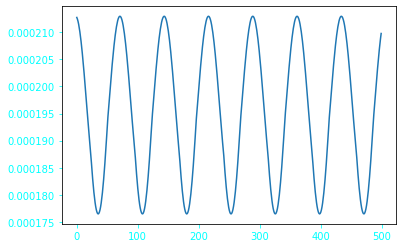

```python
actions = demo(agent,env)
plt.plot(actions)
```

#### Policy Plot

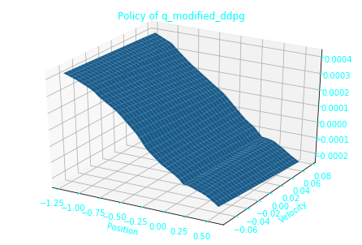

```python
plot_policy(agent, agent_name=agent_name)
```

Although q-modified has experienced far more goal states than the simple modified agent, the test behavior and policy plot look almost identical. The q-modifications, even with the increased presence of goal states did not yield any positive results with our configuration.

# Summary and Conclusion

In this project, we attempted to replicate the refined reinforcement learning algorithm Deep Deterministic Policy Gradient (DDPG) presented in the paper "Continuous Control with Deep Reinforcement Learning" published at the ICLR in 2015. Unfortunately, our agent did not learn a policy that solves the mountain car problem within 100 episodes. We identified several possible modifications that could improve the episodic rewards including: scaling the output of the actor by 0.5, reducing the neuron counts in the 1st and 2nd layer, overrepresenting goal states by adding 10 identical entries per goal state, reducing the noise process over the course of training to 0.005 and finally we applied a "Q modification" to the experiences of the agent. However, in our opinion, the applied modifications did not really improve the results. In the end, the most promising policy was generated by the original ddpg agent, although it was still unable to solve the problem.

There are examples of ATARI games, where the original DDPG Agent had to go through millions of steps in order to learn the right policy. Our training was in the range of 70000 steps in total, which is two orders of magnitude below that. Perhaps more training could yield positive results. However, the presented problem is so simple that it could be hardly seen as a success if the agent learned the right policy after 10000 episodes.

In the end, we could not identify the exact modifcation necessary to improve the performance of our agent. However, we tested several possible options and identified further aspects that are worth investigating to solve the mountain car problem in the uture using the presented DDPG agent with an implementation in Tensorflow 2.0.1

## Superior hardcoded agent

In hommage to Alex Irpan's Blogpost "Deep RL doesn't work yet", we have written a hardcoded agent with a 1-line policy to demonstrate the simplicity of the problem and how, as he noted, most problems nowadays are still better solved with domain knowledge.

```
INFO:root:Episode 1 out of 10
INFO:root:Episode 2 out of 10
INFO:root:Episode 3 out of 10
INFO:root:Episode 4 out of 10
INFO:root:Episode 5 out of 10
INFO:root:Episode 6 out of 10
INFO:root:Episode 7 out of 10
INFO:root:Episode 8 out of 10
INFO:root:Episode 9 out of 10
INFO:root:Episode 10 out of 10
```

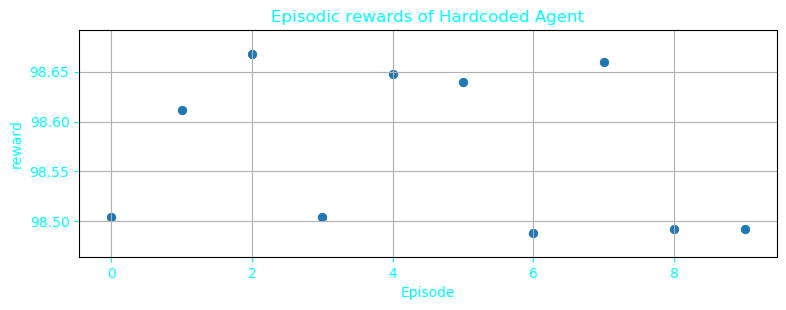

```python
class HCAgent:
    def act(self,s, exploration):
        return np.array([-0.2 if s[1] < 0  else 0.2])
agent = HCAgent()

test_results = test_agent(agent,env,episodes=10,agent_name="HC",verbose=False)
plot_results(test_results, "Hardcoded Agent")
actions = demo(agent,env)
```

# References

[1] “Human-level control through deep reinforcement learning”. In: Nature (2015). doi: 10.1038/nature14236.

[2] Alex Irpan. Deep Reinforcement Learning Doesn’t Work Yet. https:// www.alexirpan.com/2018/02/14/rl-hard.html. 2018.

[3] Timothy P. Lillicrap et al. Continuous control with deep reinforcement learning. 2015. arXiv: 1509.02971 [cs.LG].

[4] David Silver et al. “Deterministic Policy Gradient Algorithms”. In: 31st International Conference on Machine Learning, ICML 2014 1 (June 2014).

[5] Yuval Tassa, Tom Erez, and Emanuel Todorov. “Synthesis and stabilization of complex behaviors through online trajectory optimization”. In: 2012 IEEE/RSJ International Conference on Intelligent Robots and Systems. IEEE. 2012, pp. 4906–4913.